# Analysis of Mental Health Risk

Kayla Lu

2026-03-07

# Introduction

Mental health is influenced by multiple demographic, lifestyle,and work-related factors.

This project explores the distribution of mental health risk and examines how different factors such as gender, sleep, stress level, and work environment are associated with mental health outcomes.

# Data Preparation

```r
# Load required packages
library(tidyverse)
library(ggplot2)

# Read dataset
mental_data <- read_csv("mental_health_dataset.csv")
```

## Data Inspection

```r
head(mental_data)
```

```
## # A tibble: 6 × 14
##     age gender     employment_status work_environment mental_health_history
##   <dbl> <chr>      <chr>             <chr>            <chr>
## 1    56 Male       Employed          On-site          Yes
## 2    46 Female     Student           On-site          No
## 3    32 Female     Employed          On-site          Yes
## 4    60 Non-binary Self-employed     On-site          No
## 5    25 Female     Self-employed     On-site          Yes
## 6    38 Female     Unemployed        On-site          Yes
## # ℹ 9 more variables: seeks_treatment <chr>, stress_level <dbl>,
## #   sleep_hours <dbl>, physical_activity_days <dbl>, depression_score <dbl>,
## #   anxiety_score <dbl>, social_support_score <dbl>, productivity_score <dbl>,
## #   mental_health_risk <chr>
```

```r
str(mental_data)
```

```
## spc_tbl_ [10,000 × 14] (S3: spec_tbl_df/tbl_df/tbl/data.frame)
##  $ age                   : num [1:10000] 56 46 32 60 25 38 56 36 40 28 ...
##  $ gender                : chr [1:10000] "Male" "Female" "Female" "Non-binary" ...
##  $ employment_status     : chr [1:10000] "Employed" "Student" "Employed" "Self-employed" ...
##  $ work_environment      : chr [1:10000] "On-site" "On-site" "On-site" "On-site" ...
##  $ mental_health_history : chr [1:10000] "Yes" "No" "Yes" "No" ...
##  $ seeks_treatment       : chr [1:10000] "Yes" "Yes" "No" "No" ...
##  $ stress_level          : num [1:10000] 6 10 7 4 3 3 2 8 7 8 ...
##  $ sleep_hours           : num [1:10000] 6.2 9 7.7 4.5 5.4 9.9 5.5 7.1 6.5 3.1 ...
##  $ physical_activity_days: num [1:10000] 3 4 2 4 0 3 1 5 6 0 ...
##  $ depression_score      : num [1:10000] 28 30 24 6 24 17 25 25 28 7 ...
##  $ anxiety_score         : num [1:10000] 17 11 7 0 12 9 3 8 6 18 ...
##  $ social_support_score  : num [1:10000] 54 85 62 95 70 63 87 72 46 88 ...
##  $ productivity_score    : num [1:10000] 59.7 54.9 61.3 97 69 69.3 63.1 58.4 60.4 93.2 ...
##  $ mental_health_risk    : chr [1:10000] "High" "High" "Medium" "Low" ...
##  - attr(*, "spec")=
##   .. cols(
##   ..   age = col_double(),
##   ..   gender = col_character(),
##   ..   employment_status = col_character(),
##   ..   work_environment = col_character(),
##   ..   mental_health_history = col_character(),
##   ..   seeks_treatment = col_character(),
##   ..   stress_level = col_double(),
##   ..   sleep_hours = col_double(),
##   ..   physical_activity_days = col_double(),
##   ..   depression_score = col_double(),
##   ..   anxiety_score = col_double(),
##   ..   social_support_score = col_double(),
##   ..   productivity_score = col_double(),
##   ..   mental_health_risk = col_character()
##   .. )
##  - attr(*, "problems")=<externalptr>
```

```r
summary(mental_data)
```

```
##       age           gender          employment_status  work_environment
##  Min.   :18.00   Length:10000       Length:10000       Length:10000
##  1st Qu.:30.00   Class :character   Class :character   Class :character
##  Median :41.50   Mode  :character   Mode  :character   Mode  :character
##  Mean   :41.56
##  3rd Qu.:53.00
##  Max.   :65.00
##  mental_health_history seeks_treatment     stress_level     sleep_hours
##  Length:10000          Length:10000       Min.   : 1.000   Min.   : 3.000
##  Class :character      Class :character   1st Qu.: 3.000   1st Qu.: 5.500
##  Mode  :character      Mode  :character   Median : 6.000   Median : 6.500
##                                           Mean   : 5.572   Mean   : 6.473
##                                           3rd Qu.: 8.000   3rd Qu.: 7.500
##                                           Max.   :10.000   Max.   :10.000
##  physical_activity_days depression_score anxiety_score   social_support_score
##  Min.   :0.000          Min.   : 0.00    Min.   : 0.00   Min.   :  0.00
##  1st Qu.:2.000          1st Qu.: 7.00    1st Qu.: 5.00   1st Qu.: 25.00
##  Median :4.000          Median :15.00    Median :11.00   Median : 50.00
##  Mean   :3.506          Mean   :15.04    Mean   :10.56   Mean   : 50.12
##  3rd Qu.:5.000          3rd Qu.:23.00    3rd Qu.:16.00   3rd Qu.: 76.00
##  Max.   :7.000          Max.   :30.00    Max.   :21.00   Max.   :100.00
##  productivity_score mental_health_risk
##  Min.   : 42.80     Length:10000
##  1st Qu.: 65.80     Class :character
##  Median : 77.60     Mode  :character
##  Mean   : 77.31
##  3rd Qu.: 89.20
##  Max.   :100.00
```

```r
colSums(is.na(mental_data))
```

```
##                    age                 gender      employment_status
##                      0                      0                      0
##       work_environment  mental_health_history        seeks_treatment
##                      0                      0                      0
##           stress_level            sleep_hours physical_activity_days
##                      0                      0                      0
##       depression_score          anxiety_score   social_support_score
##                      0                      0                      0
##     productivity_score     mental_health_risk
##                      0                      0
```

## Data Cleaning

```r
mental_data$gender <- as.factor(mental_data$gender)
mental_data$employment_status <- as.factor(mental_data$employment_status)
mental_data$work_environment <- as.factor(mental_data$work_environment)
mental_data$mental_health_history <- as.factor(mental_data$mental_health_history)
mental_data$seeks_treatment <- as.factor(mental_data$seeks_treatment)

mental_data$mental_health_risk <- factor(
  mental_data$mental_health_risk,
  levels = c("Low","Medium","High")
)
```

# Data Visualisations and Analysis

## Sample Overview

### Age Distribution

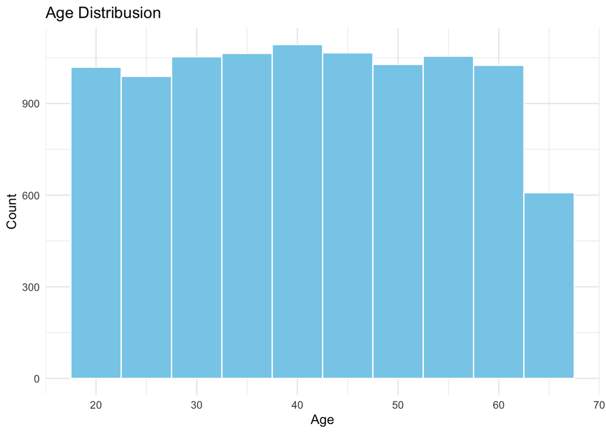

```r
ggplot(mental_data, aes(x = age)) +
  geom_histogram(binwidth = 5, fill="skyblue", color="white") +
  labs (title="Age Distribusion",
        x= "Age", y = "Count") +
  theme_minimal()
```

The age distribution shows that most participants fall within the young to middle-aged adult range, suggesting that the dataset primarily represents working-age individuals.

### Gender Distribution

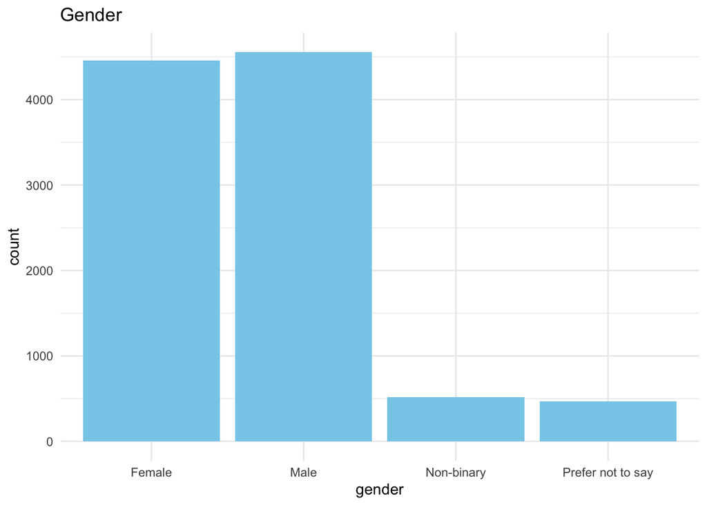

```r
ggplot(mental_data, aes(x=gender)) +
         geom_bar(fill="skyblue") +
         theme_minimal() +
         labs(title="Gender")
```

## Core Analysis

### Define custom colors

```r
risk_colors <- c(
  "Low" = "lightgreen",
  "Medium" = "khaki",
  "High" = "lightcoral"
)
scale_fill_manual(values = risk_colors)
```

[output not shown]

### 1. Mental health Risk Distribution

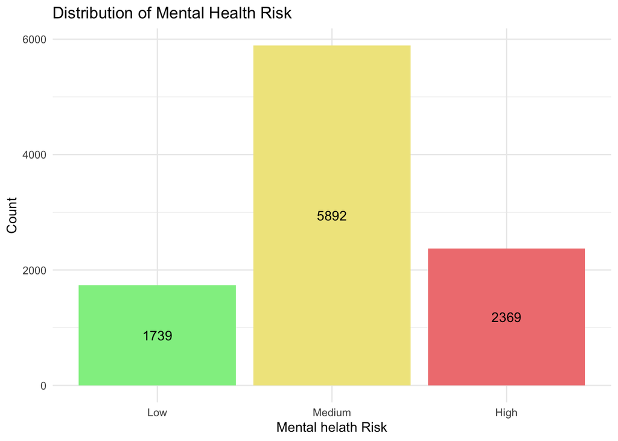

```r
ggplot(mental_data, aes(x = mental_health_risk, fill= mental_health_risk)) +
  geom_bar() +
  scale_fill_manual(values = risk_colors) +
  geom_text(stat = "count",
    aes(label = ..count..),
    position = position_stack(vjust = 0.5)) +
  labs(title = "Distribution of Mental Health Risk",
    x = "Mental helath Risk", y = "Count") +
  theme_minimal() +
  theme(legend.position = "none")
```

The distribution of mental health risk varies across participants, with most individuals falling into the **Medium** risk category.

### 2. Gender vs Mental Health Risk

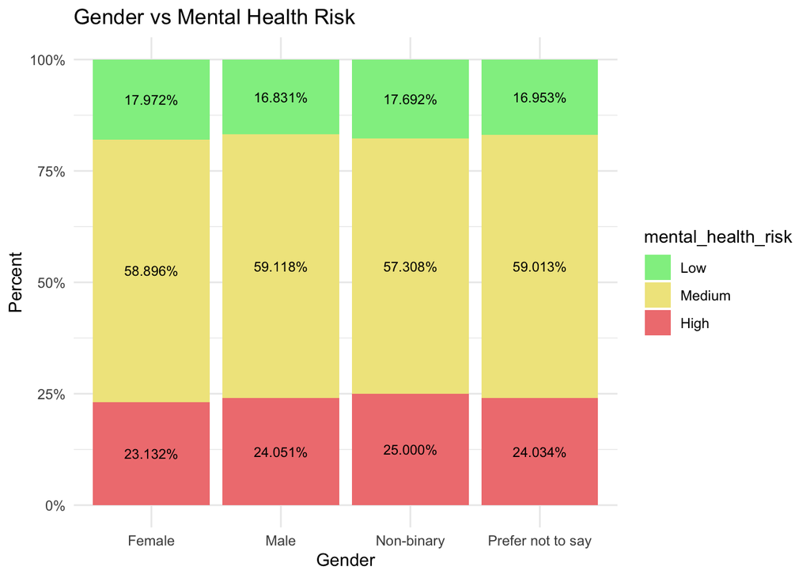

```r
Gendaer_mental_porportion <- mental_data %>%
  count(mental_health_risk, gender) %>%
  group_by(gender) %>%
  mutate(prop = n / sum(n))

ggplot(Gendaer_mental_porportion, aes(x = gender, y = prop, fill = mental_health_risk)) +
  geom_col() +
  geom_text(aes(label = scales::percent(prop)),
            position = position_stack(vjust = 0.5), size = 3) +
  scale_y_continuous(labels = scales::percent) +
  scale_fill_manual(values = risk_colors) +
  labs(title = "Gender vs Mental Health Risk",
       x = "Gender", y="Percent") +
  theme_minimal()
```

Mental health risk is similarly distributed across genders, with most participants at medium risk, then high, and the fewest at low risk.

### 3. Depression vs Mental Health Risk

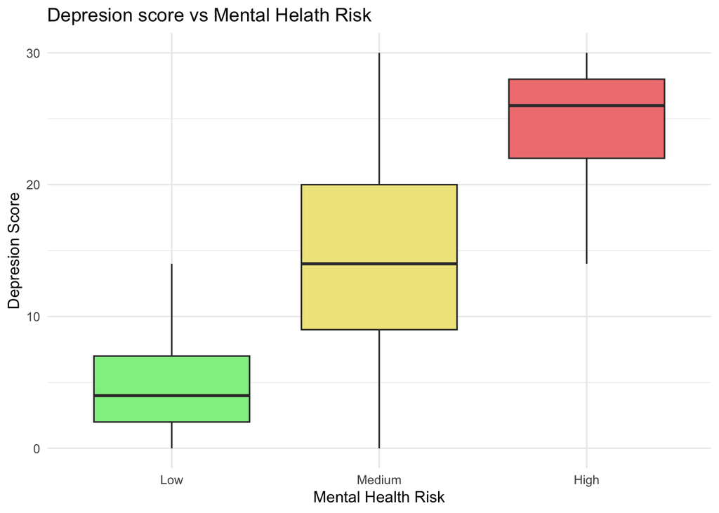

```r
ggplot(mental_data, aes(x = mental_health_risk, y = depression_score, fill = mental_health_risk)) +
  geom_boxplot() +
  scale_fill_manual(values = risk_colors) +
  labs(title = "Depresion score vs Mental Helath Risk",
       x = "Mental Health Risk", y = "Depresion Score") +
  theme_minimal() +
  theme(legend.position = "none")
```

Depression scores are clearly associated with mental health risk: high scores correspond to high risk, medium scores to medium risk, and low scores to low risk.

### 4. Anxiety vs Mental Health Risk

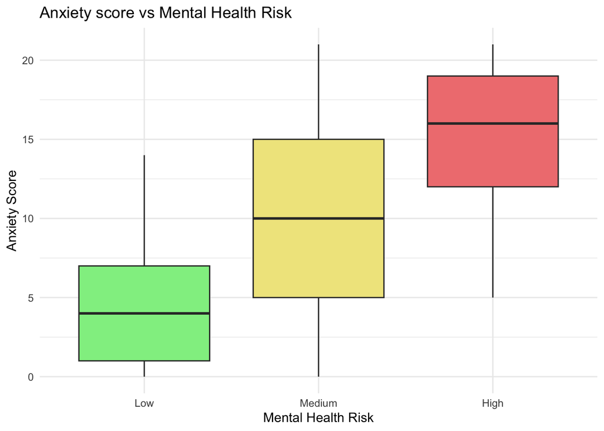

```r
ggplot(mental_data, aes(x = mental_health_risk, y= anxiety_score, fill = mental_health_risk)) +
  geom_boxplot() +
  scale_fill_manual(values = risk_colors) +
  labs(title = "Anxiety score vs Mental Health Risk",
       x = "Mental Health Risk", y ="Anxiety Score") +
  theme_minimal() +
  theme(legend.position = "none")
```

Anxiety scores are also associated with mental health risk, with higher scores indicating greater risk, moderate scores corresponding to medium risk, and lower scores to low risk.

### 5. Seek treatment vs Mental health Risk

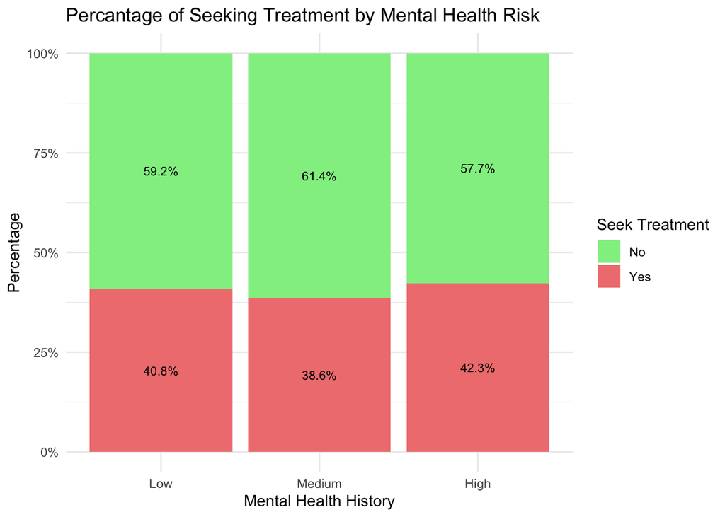

```r
Seek_treatment_mental_porportion <- mental_data %>%
  count(seeks_treatment, mental_health_risk) %>%
  group_by(mental_health_risk) %>%
  mutate(prop = n / sum(n))

ggplot(Seek_treatment_mental_porportion, aes(x = mental_health_risk, y = prop, fill = seeks_treatment)) +
  geom_col() +
  geom_text(aes(label = scales::percent(prop)),
            position = position_stack(vjust = 0.5), size = 3) +
  scale_fill_manual(values = c("No" = "lightgreen", "Yes" = "lightcoral")) +
  scale_y_continuous(labels = scales::percent) +
  labs(title = "Percantage of Seeking Treatment by Mental Health Risk",
       x = "Mental Health History", y = "Percentage", fill = "Seek Treatment") +
  theme_minimal()
```

Across all three mental health risk levels, the majority of participants have not sought treatment; however, the high-risk group has a slightly higher proportion of participants who have sought treatment compared to the other two groups.

### 6. Mental Health History vs Mental health Risk

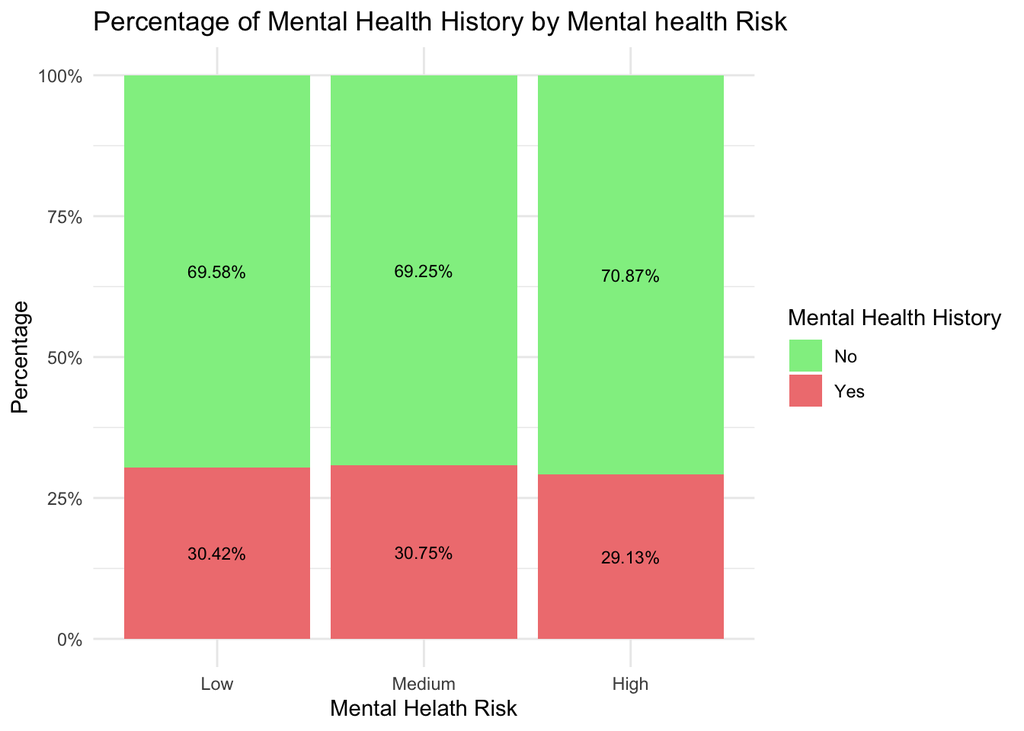

```r
History_proportion <- mental_data %>%
  count(mental_health_history, mental_health_risk) %>%
  group_by(mental_health_risk) %>%
  mutate (prop = n / sum(n))

ggplot(History_proportion, aes(x = mental_health_risk, y = prop, fill = mental_health_history)) +
  geom_col() +
  geom_text(aes(label = scales::percent(prop)),
            position = position_stack(vjust = 0.5), size = 3) +
  scale_fill_manual(values = c("No" = "lightgreen", "Yes" = "lightcoral")) +
  scale_y_continuous(labels = scales::percent) +
  labs(title = "Percentage of Mental Health History by Mental health Risk",
       x  ="Mental Helath Risk", y = "Percentage" , fill = "Mental Health History") +
  theme_minimal()
```

The distribution of mental health history is similar across all three risk levels, with about two-thirds of participants reporting no history. The high-risk group has a slightly higher proportion of participants with no history compared to the other two groups.

### Health and Lifestyle Factors

### 7. Sleep vs Mental Health Risk

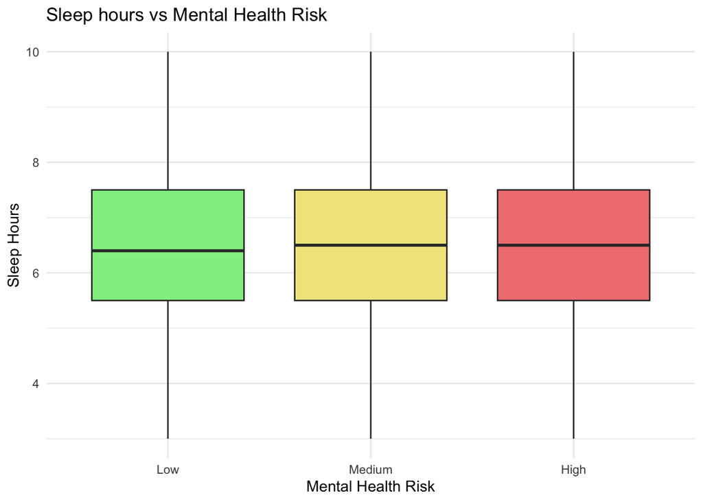

```r
ggplot(mental_data, aes(x = mental_health_risk, y = sleep_hours, fill = mental_health_risk)) +
  geom_boxplot() +
  scale_fill_manual(values = risk_colors) +
  labs(title = "Sleep hours vs Mental Health Risk",
       x = "Mental Health Risk", y = "Sleep Hours") +
  theme_minimal() +
  theme(legend.position = "none")
```

Sleep duration is similarly distributed across all three mental health risk levels, with most participants sleeping between 5.5 and 7.5 hours.

### 8. Stress Level

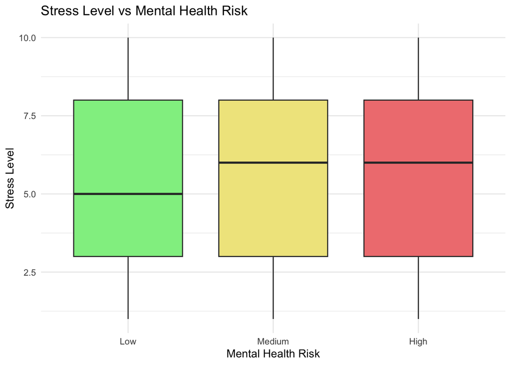

```r
ggplot(mental_data, aes(x = mental_health_risk, y = stress_level, fill = mental_health_risk)) +
  geom_boxplot() +
  scale_fill_manual(values = risk_colors) +
  labs(title = "Stress Level vs Mental Health Risk",
       x = "Mental Health Risk", y = "Stress Level") +
  theme_minimal() +
  theme(legend.position = "none")
```

### 9. Social Support vs Mental Health Risk

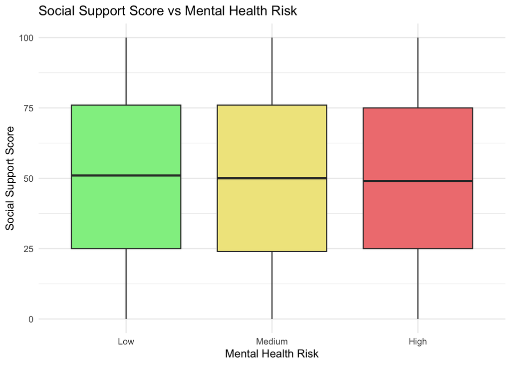

```r
ggplot(mental_data, aes(x = mental_health_risk, y = social_support_score, fill = mental_health_risk)) +
  geom_boxplot() +
  scale_fill_manual(values = risk_colors) +
  labs(title = "Social Support Score vs Mental Health Risk",
       x = "Mental Health Risk", y ="Social Support Score") +
  theme_minimal() +
  theme(legend.position = "none")
```

Social support scores are similar across all mental health risk levels.

### 10. Employment Status vs Menatl Health Risk

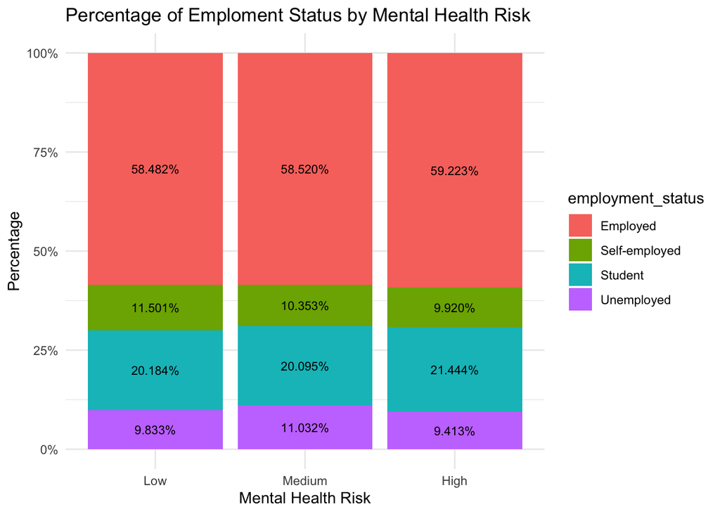

```r
Employment_mental_propotion <- mental_data %>%
  count(employment_status, mental_health_risk) %>%
  group_by(mental_health_risk) %>%
  mutate(prop = n / sum(n))

ggplot(Employment_mental_propotion, aes(x = mental_health_risk, y= prop, fill = employment_status)) +
  geom_col() +
  geom_text(aes(label = scales::percent(prop)),
            position = position_stack(vjust = 0.5), size = 3) +
  scale_y_continuous(labels = scales::percent) +
  labs(title = "Percentage of Emploment Status by Mental Health Risk",
       x = "Mental Health Risk", y = "Percentage") +
  theme_minimal()
```

Employment status is generally similar across all mental health risk levels, with most participants being employed, followed by students, and the fewest unemployed or self-employed. In the high-risk group, the proportion of employed and students is slightly higher than in the other two groups.

### 11. Work Environment vs Mental Health Risk

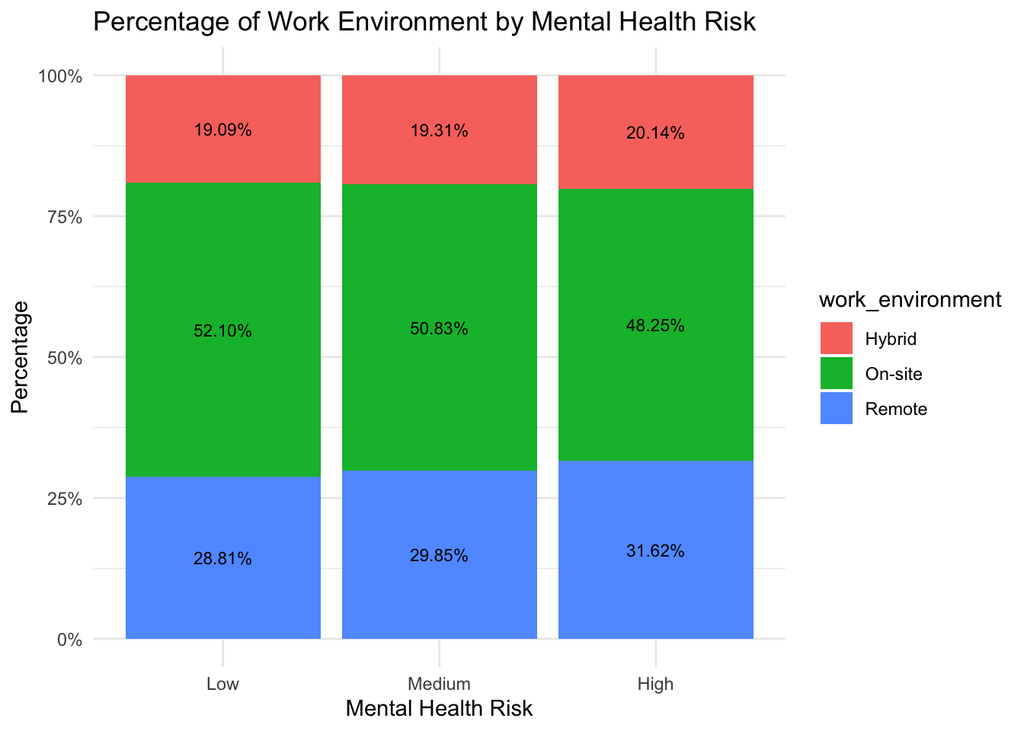

```r
Environment_mental_proportion <- mental_data %>%
  count(work_environment, mental_health_risk) %>%
  group_by(mental_health_risk) %>%
  mutate(prop = n / sum(n))

ggplot(Environment_mental_proportion, aes(x = mental_health_risk, y = prop, fill= work_environment))+
  geom_col() +
  geom_text(aes(label = scales::percent(prop)),
            position = position_stack(vjust = 0.5), size = 3) +
  scale_y_continuous(labels = scales::percent) +
  labs(title = "Percentage of Work Environment by Mental Health Risk",
       x = "Mental Health Risk", y = "Percentage") +
  theme_minimal()
```

Overall, most participants work onsite, accounting for nearly half, followed by remote and hybrid work. However, in the high-risk group, the proportion of onsite workers is lower than in the other two groups.

### 12. Productivity vs Mental Health Risk

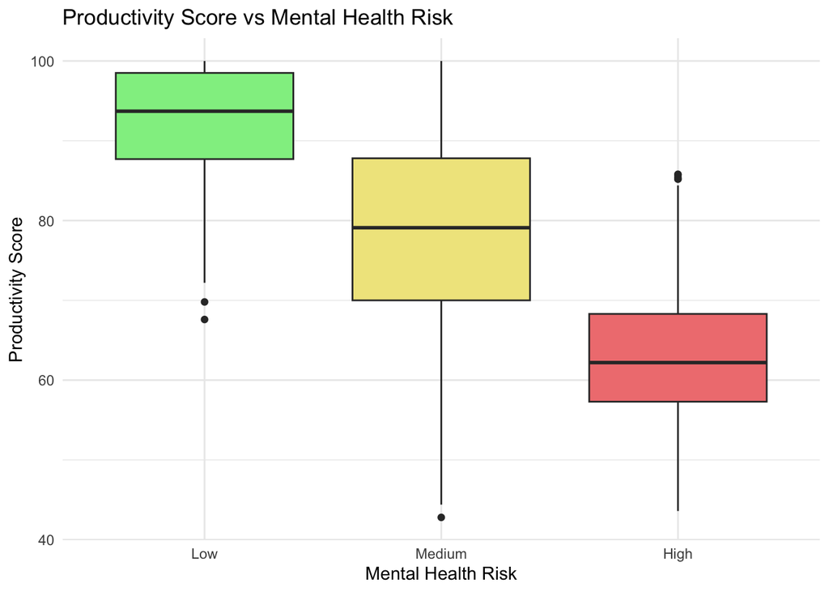

```r
ggplot(mental_data, aes(x = mental_health_risk, y = productivity_score, fill = mental_health_risk)) +
  geom_boxplot() +
  scale_fill_manual(values = risk_colors) +
  labs(title = "Productivity Score vs Mental Health Risk",
       x = "Mental Health Risk", y ="Productivity Score") +
  theme_minimal() +
  theme(legend.position = "none")
```

The productivity scores show a distinct downward trend across the three risk levels. The median score drops noticeably from low to high risk, and the middle 50% of scores show almost no overlap between risk levels.

# Conclusion

This analysis explored demographic, lifestyle, and work-related factors associated with mental health risk.

Overall, these findings highlight that **psychological wellbeing is the main driver of mental health risk**, while productivity is inversely related. Addressing psychological factors may help improve both mental health outcomes and work performance.